# Example: classification of handprinted characters

The purpose of this page is to solve a classification task using Python. The chosen database to be classified is the [NIST database](https://www.nist.gov/srd/nist-special-database-19), which contains handprinted sample forms of 3600 writers, about 397.000 character images isolated from their forms and ground truth classifications for those images.

In order to decrease the time and memory comsumption of this example, the database was restricted to only 100 images per class. NIST database contain 62 different classes of characters.

In this page 2 classifiers were trained with a set of simple features, and the acuracy are presented according to number of kfolds and number os features.

[video not shown]

# Workspace setup and database loading

```python
import sys
sys.path.append('../../')
import numpy as np
import matplotlib.pyplot as plt
from sarpy.datasets import load_nist
from scipy import ndimage
from skimage.feature import shape_index
from skimage.measure import label
from skimage.measure import regionprops
from matplotlib.colors import ListedColormap
from sklearn.model_selection import train_test_split
from sklearn.preprocessing import StandardScaler
from sklearn.datasets import make_moons, make_circles, make_classification
from sklearn.neural_network import MLPClassifier
from sklearn.neighbors import KNeighborsClassifier
from sklearn.svm import SVC
from sklearn.gaussian_process import GaussianProcessClassifier
from sklearn.gaussian_process.kernels import RBF
from sklearn.tree import DecisionTreeClassifier
from sklearn.ensemble import RandomForestClassifier, AdaBoostClassifier
from sklearn.naive_bayes import GaussianNB
from sklearn.discriminant_analysis import QuadraticDiscriminantAnalysis
from sklearn.model_selection import cross_val_score
from sklearn.decomposition import PCA
from sklearn.feature_selection import SelectKBest
from sklearn.feature_selection import chi2
from sklearn.feature_selection import f_classif
from sklearn.model_selection import cross_val_predict
from sklearn.metrics import confusion_matrix
import itertools

dataset = load_nist()
```

# Classifiers training

## Feature Extraction

To extract the features of our dataset we used the scikit-image library, module measure, function regionprops. To apply this function, we firstly labeled the connected components of each image. Most of the images presented one connected component since they show only one letter by image, and the letters seldom presents more than one component. After labeled, the images were measured using the regionprops method, which returns an array of all sort of component measures. Therefore, we selected features which would help us to classify the distinct classes. We show features mathematical concepts below:

- Area: number of pixels.
- Bounding box area: Number of pixels in the Bounding box (min_row, min_col, max_row, max_col). Pixels belonging to the bounding box are in the half-open interval [min_row; max_row) and [min_col; max_col).
- Convex area: Number of pixels of convex hull image.
- Eccentricity: Eccentricity of the ellipse that has the same second-moments as the region. The eccentricity is the ratio of the focal distance (distance between focal points) over the major axis length. The value is in the interval [0, 1). When it is 0, the ellipse becomes a circle.
- Equivalent diameter: The diameter of a circle with the same area as the region.
- Euler number: Euler characteristic of region. Computed as number of objects (= 1) subtracted by number of holes (8-connectivity).
- Extent: Ratio of pixels in the region to pixels in the total bounding box. Computed as area / (rows * cols).
- Filled area: Number of pixels of filled region.
- Minor and Major axis length: The length of the minor and major axis of the ellipse that has the same normalized second central moments as the region.
- Orientation: Angle between the X-axis and the major axis of the ellipse that has the same second-moments as the region. Ranging from -pi/2 to pi/2 in counter-clockwise direction.
- Perimeter: Perimeter of object which approximates the contour as a line through the centers of border pixels using a 4-connectivity.
- Solidity: Ratio of pixels in the region to pixels of the convex hull image.
- Central moments: Central moments (translation invariant) up to 3rd order:

$\mu_{ji} = \displaystyle\sum{ array(x, y) * (x - x_c)^j * (y - y_c)^i }$

where the sum is over the x, y coordinates of the region, and x_c and y_c are the coordinates of the region’s centroid.

- Inertia tensor: Inertia tensor of the region for the rotation around its mass.
- Centroid: Centroid coordinate tuple (row, col).

Reference http://scikit-image.org/docs/stable/api/skimage.measure.html#skimage.measure.regionprops

```python
def features(bitmap):
    f = []

    label_img = label(bitmap)
    props = regionprops(label_img)
    f.append(props[0].area)
#     f.append(props[0].bbox_area)
    f.append(props[0].convex_area)
    f.append(props[0].eccentricity)
    f.append(props[0].equivalent_diameter)
    f.append(props[0].euler_number)
    f.append(props[0].extent)
    f.append(props[0].filled_area)
    f.append(props[0].minor_axis_length)
    f.append(props[0].major_axis_length)
    f.append(props[0].orientation)
    f.append(props[0].perimeter)
    f.append(props[0].solidity)

    moments = np.ravel(props[0].moments_central)
    f.extend(moments)
    inertia = np.ravel(props[0].inertia_tensor)
    f.extend(inertia)
    centroid_raw, centroid_col = props[0].centroid
    f.append(centroid_raw)
    f.append(centroid_col)

    return f

def feature_extraction(data):
    X = data['bitmaps']
    Y = data['targets']

    M = []
    for i in range(len(X)):
        feat = features(X[i].data)
        feat.append(Y[i])
        M.append(feat)
    M = np.asarray(M)
    return M

mindata = {'bitmaps':dataset['bitmaps'][:],'targets':dataset['targets'][:]}
featured = feature_extraction(mindata)
datasets = [featured]
```

## Confusion matrix

```python
def plot_confusion_matrix(cm, classes,
                          normalize=False,
                          title='Confusion matrix',
                          cmap=plt.cm.Blues):
    """
    This function prints and plots the confusion matrix.
    Normalization can be applied by setting `normalize=True`.
    """
    if normalize:
        cm = cm.astype('float') / cm.sum(axis=1)[:, np.newaxis]
        print("Normalized confusion matrix")
    else:
        print('Confusion matrix, without normalization')

    plt.imshow(cm, interpolation='nearest', cmap=cmap)
    plt.title(title)
    plt.colorbar()
    tick_marks = np.arange(len(classes))
    plt.xticks(tick_marks, classes, rotation=45)
    plt.yticks(tick_marks, classes)

    fmt = '.2f' if normalize else 'd'
    thresh = cm.max() / 2.
    plt.tight_layout()
    plt.ylabel('True label')
    plt.xlabel('Predicted label')
```

# Classification algorithm

## PCA

Principal Component Analysis (PCA) is a statistical technique that uses orthogonal transformations in order to convert possible correlated variables into linearly uncorrelated variables. This transformation is used to increase the variance between variables, so the difference between each pattern can be emphasized.

The intuition behind PCA technique is that, given an amount of feature vectors, the PCA algorithm will transform the dataset to change the basis of the observed variables, so the first feature in the new dataset will have the greatest variance among all features, the second feature will have the second greatest variance, and so forth.

PCA algorithm can be summarized in the following steps:

- Gather the feature vectors of the experiment in the matrix X
- Calculate C, the covariance matrix of X
- Compute the eigenvalues of C and the orthogonal set of eigenvectors
- Build the matrix E, where the columns are the eigenvectors, sorted by the eigenvalues
- The new dataset will be computed as X' = (X - Xm) * E, where Xm is the mean feature vector

The dimensionality of the resulting feature vector can be reduced by using only the first n features of the X' matrix.

In our example, the PCA is used in the extracted feature vectors to increase the variance among the features. The first method used is 'pca.fit(X)', which fits the model in the dataset X, while the pca.transform(X) applies the dimensionality reduction to the dataset, returning the transformed data.

## Standard Scaling of Features

To standardize features we use the StantardScaler method of scikit-learn with works by removing the mean and scaling to unit variance. Centering and scaling happen independently on each feature by computing the relevant statistics on the samples.

## Support Vector Machine Formulation

A support vector machine (SVM) constructs a hyper-plane or set of hyper-planes in a high dimensional space, which can be used for a variety of tasks, including classification.

At this Demo we used the SVC function of scikit-learn library, with parameters kernel=“linear” and C=0.025. The mathematical formulation for this function was obtained of scikit-learn webpage, which we show below.

Intuitively, a good separation is achieved by the hyper-plane that has the largest distance to the nearest training data points of any class (so-called functional margin), since in general the larger the margin the lower the generalization error of the classifier. Therefore:

Given training vectors $x_i \in \mathbb{R}^p , i=1,\dots,n$, in two classes, and a vector $y \in \{1, -1\}^n $ , SVC solves the following primal problem:

\begin{array}{rrl} \displaystyle\min_{w, b, \varsigma} \frac{1}{2}w^T w+C\displaystyle\sum_{i=1}^{n} \varsigma i \\ \text{subject to } y_i(w^T \phi(x_i)+b) \geq 1 - \varsigma_i, \\ \varsigma_i \geq 0, i = 1, \dots, n \end{array}

Its dual is

\begin{array}{rrl} \displaystyle\min_{\alpha} \frac{1}{2}\alpha^T Q\alpha - e^T \alpha \\ \text{subject to } y^T\alpha = 0 \\ 0 \leq \alpha_i \leq C, i = 1, \dots, n \end{array}

where $e$ is the vector of all ones, $C > 0$ is the upper bound, $Q$ is an $n$ by $n$ positive semidefinite matrix, $Q_{ij} \equiv y_iy_jK(x_i, x_j)$, where $K(x_i, x_j) = \phi(x_i)^T\phi(x_j)$ is the kernel, which is linear $\langle x, x' \rangle$ , in this case. Here training vectors are implicitly mapped into a higher (maybe infinite) dimensional space by the function $\phi$ .

The decision function is:

\begin{array}{rrl} \text{sgn}(\displaystyle\sum_{i=1}^{n} y_i\alpha_iK(x_i,x)+\rho) \end{array}

These parameters can be accessed through the members $\text{dual_coef}$ which holds the product $y_i{\alpha}_i$ , $\text{support_vectors}$ which holds the support vectors, and $\text{intercept}$ which holds the independent term $\rho$.

Reference http://scikit-learn.org/stable/modules/svm.html#svm

## Cross-Validation

Cross-validation is used to estimate how a statistics analysis will correct predict some output from a dataset. It can be used to measure the accuracy of a prediction model. On machine learning, crossvalidation is used to avoid overfitting, which is the the prediction of a function and test it on the same dataset. There multiple crossvalidation techiniques. On this project, we use the k-fold method, which splits the training set on k subsamples. One of this k sample is used to validate the model and the k-1 samples are used to training. Then, the process is repeated k times. At each time, one of the k subsampes is used to validate the model. From the k iterations, we estimate the mean square error of the process.

We take all the prediction errors from all K stages, we add them together, and that gives us what's called the cross-validation error rate.

Let the K parts be $C_1,C2, \dots, C_K$ where $C_k$ denotes the indices of the observations in part k. There are $n_k$ observations in part k: if N is a multiple of K, then $n_k = \frac{n}{K}$.

Thus, we have

\begin{array}{rrl} CV_{(K)} & = & \sum^K_{k=1} \frac{n_k}{n}\href{MSE}{MSE}_k \\ \\ \text{in which } MSE_k & = & \frac{ \displaystyle \sum_{i\in C_k}(y_i - \hat{y}_i)^2}{n_k} \end{array}

in which:

- $\hat{y}_i$ is the fit for observation i, obtained from the data with fold k removed.
- the mean squared error is got by applying the fit to the K minus 1 parts that don't involve part number K. That gives us our fit $\hat{y}_i$ for observation i.
- we add up the error (MSE).
- we have a weighted average formula with $\frac{n_k}{n}$ because each of the folds might not be exactly the same size. If we are lucky that the n divides by k exactly, then that weight will just be 1/k.

[figure not shown]

Since this cross-validation error is just an average, the standard error of that average also gives us a standard error of the cross-validation estimate:

- We take the error rates from each of the folds.
- Their average is the cross-validation error rate.
- The standard error is the standard deviation of the cross-validation estimate.

The standard deviation is a useful estimate but not quite valid because we're computing the standard error as if the folds were independent observations but they're not strictly independent. $Error_k$ overlaps with, $Error_j$ because they share some training samples. There's some correlation between them. But it's still use because it's actually a quite good estimate, mathematically proved.

Reference https://gerardnico.com/wiki/data_mining/cross_validation

```python
def fun_classification(data,names,classifiers,arraykfolds,plotCM=False,iterFeatures=False):

    data = data[0]
    print(data.shape)


    for kfolds in arraykfolds:
        print("-----------------")
        print("      DATASET    ")

        # Load X : features and y : labels
        X = data[:,0:data.shape[1]-1]
        y = data[:,data.shape[1]-1]

        # PCA
        pca = PCA()
        pca.fit(X)
        X = pca.transform(X)

        # Standardize features
        X = StandardScaler().fit_transform(X)

        print("samples        : ",X.shape[0]) # number of samples
        print("total features : ",X.shape[1]) # number of features
        arrayNumFeatures = []
        if iterFeatures == True:
            arrayNumFeatures = [10,20,X.shape[1]]
        else:
            arrayNumFeatures = [X.shape[1]]

        # Initial Plot parameters
        plt.figure(figsize=(8,8))

        # iterate over classifiers names and configurations
        print("\n>> Classifiers")
        print("cross validation, kfolds = ",kfolds,"\n")

        for name, clf in zip(names, classifiers):
            print("+",name)
            #plot x and y
            x_graph = [0]
            y_graph =[[0,0]]

            # increase number of features at each iteration for comparations
            for j in arrayNumFeatures:

                #Feature Selection KBest
                ttx = SelectKBest(f_classif,k=j).fit_transform(X,y)

                #Cross validation 5-folds  (5 classifications) SCORES
                scores = cross_val_score(clf, ttx, y, cv=kfolds)

                if(plotCM): # plot confusion Matrix
                    #Cross validation 5-folds  (5 classifications) PREDICT -> for matrix confusion
                    y_pred = cross_val_predict(clf,ttx,y, cv=kfolds)
                    cnf_matrix = confusion_matrix(y,y_pred);
                    np.set_printoptions(precision=1)
                    # Plot normalized confusion matrix
                    plt.figure(figsize=(18,18))
                    print(cnf_matrix.shape)
                    strtitle='Confusion matrix - classi:'+str(name)+' - kfolds:'+str(kfolds)+' - #features:'+str(j);
                    plot_confusion_matrix(cnf_matrix,classes=dataset['names'],normalize=True,title=strtitle)
                    plt.savefig(strtitle+'.png',pad_inches=1,bbox_inches='tight', dpi=300)
                    plt.show()

                #add results to plot
                x_graph = np.append(x_graph,j)
                y_graph = np.concatenate((y_graph,[[np.mean(scores),np.std(scores)]]),axis=0)

            plt.plot(x_graph,y_graph[:,0],label=name)

        plt.legend()
        strtitle='Prediction - kfolds:'+str(kfolds)
        plt.title(strtitle)

        plt.xlabel('# of features')
        plt.ylabel('predictions accuracy (%)')
        plt.savefig(strtitle+'.png',pad_inches=1,bbox_inches='tight', dpi=300)
        plt.show()
```

# Results

```
(6200, 35)
-----------------
      DATASET
samples        :  6200
total features :  34

>> Classifiers
cross validation, kfolds =  10

+ Linear SVM
(62, 62)
Normalized confusion matrix
```

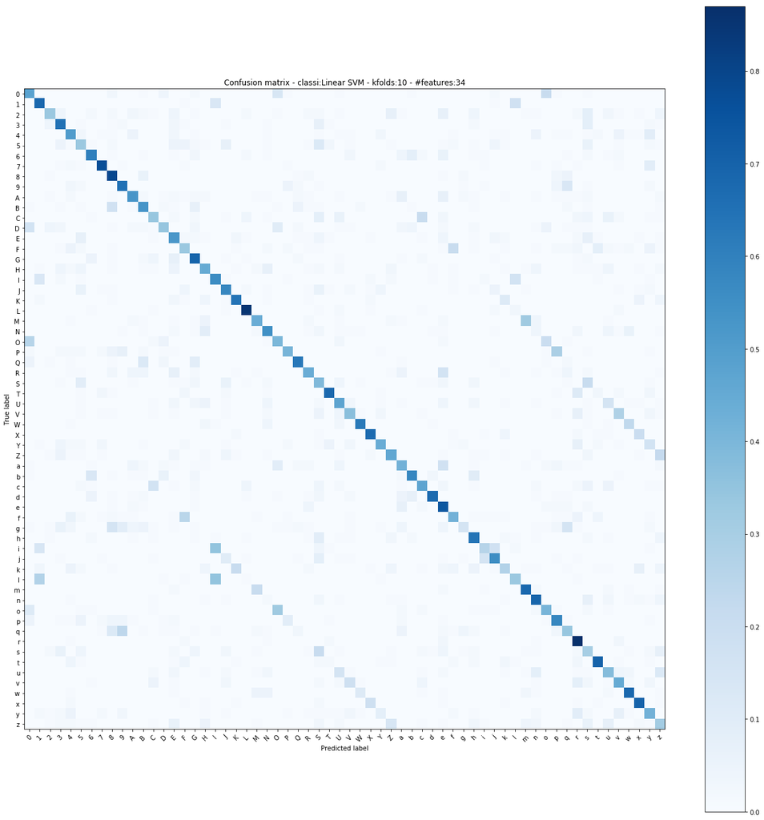

```python
#names = ["Nearest Neighbors", "Linear SVM"]
#classifiers = [ KNeighborsClassifier(3), SVC(kernel="linear", C=0.025)]
#fun_classification(datasets,names,classifiers,[5,10,15],plotCM=False,iterFeatures=True)

names = ["Linear SVM"]
classifiers = [SVC(kernel="linear", C=0.025)]
fun_classification(datasets,names,classifiers,arraykfolds=[10],plotCM=True,iterFeatures=False)
```

## Commented results

In this section, we discuss the experiment's results from different types of approaches and different classifiers.

Two classifiers were used: Linear SVM and Nearest Neighbours. In both classifiers, two different parameters were changed through the experiment: number of features and cross-validation k-fold.

For each classifier, we varied the k-fold (k=5, k=10 and k=15) and the number of features (n=10, n=20, n=34).

=============================================================================================================================

We see in this graphics that there is have a slightly improvement on results when we have a higher number of features. The Linear SVM classifier presents a better result for this dataset. It's important to note that both classifiers couldn't correctly predict some of the caractheres, such as "O" and "0" or "j" and "i".

[figure not shown]

=============================================================================================================================

**Linear SVM**

Considering the two variables (k-fold and number of features), the best results for Linear SVM were using a higher number of features (34). The k-fold variance does not seem to affect the result significantly.

These were the results for Linear SVM classifier.

**k-fold = 5**

[figure not shown]

=============================================================================================================================

**k-fold = 10**

[figure not shown]

=============================================================================================================================

**k-fold = 15**

[figure not shown]

=============================================================================================================================

**Nearest Neighbors**

Using the Nearest Neighbors classifier we see a similar result with Linear SVM, regarding the number of features. However, the accuracy of prediction is lower than Linear SVM classifier (for this dataset). Thus, using a higher number of features, the results are better.

These were the results for Nearest Neighbors classifier.

**k-fold = 5**

[figure not shown]

=============================================================================================================================

**k-fold = 10**

[figure not shown]

=============================================================================================================================

**k-fold = 15**

[figure not shown]